# house_prices

#### 454 outliers were removed

Now Fitting the linear regression model again with the new data

```python
X_out = wa_outliers[['BedroomCnt', 'BathroomCnt', 'FinishedSquareFeet', 'GarageSquareFeet',
       'LotSizeSquareFeet', 'StoryCnt', 'BuiltYear', 'ViewType', 'Latitude',
       'Longitude', 'BGMedHomeValue', 'BGMedRent', 'BGMedYearBuilt',
       'BGPctOwn', 'BGPctVacant', 'BGMedIncome', 'BGPctKids', 'BGMedAge']]
Y_out = wa_outliers['SaleDollarCnt']
```

```python
X_train_out, X_test_out, y_train_out, y_test_out = train_test_split(X_out, Y_out, test_size = 0.2, random_state = 42)
```

```python
# Fitting the linear regression model

regr_out = LinearRegression()
regr_out.fit(X_train_out, y_train_out)
```

```
LinearRegression(copy_X=True, fit_intercept=True, n_jobs=None, normalize=False)
```

```python
y_pred_out= regr_out.predict(X_test_out)
# Calculate the R^2 score for linear regression model
print('R squared: %.4f' % regr_out.score(X_test_out, y_test_out))
```

```
R squared: 0.7804
```

```python
mse_out = mean_squared_error(y_pred_out, y_test_out)
rmse_out = np.sqrt(mse_out)

print('Root Mean Squared Error:')
print(rmse_out)
mae_out = mean_absolute_error(y_pred_out, y_test_out)
print('Mean Absolute Error:')
print(mae_out)
```

```
Root Mean Squared Error:
173343.79113308815
Mean Absolute Error:
110559.5696184729
```

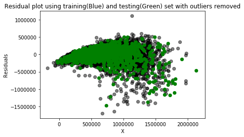

```python
# Plot outputs
plt.scatter(regr_out.predict(X_train_out), regr_out.predict(X_train_out)-y_train_out,  color='black', s=40, alpha=0.5)
plt.scatter(regr_out.predict(X_test_out), regr_out.predict(X_test_out)-y_test_out,  color='green', s=40)
plt.hlines(y=0, xmin=0, xmax=50)
plt.title('Residual plot using training(Blue) and testing(Green) set with outliers removed')
plt.ylabel('Residuals')
plt.xlabel('X')
plt.show()
```

After removing outliers, all the scores definitely improved and from the residuals plot, the data points are more towards zero and mostly randomly scattered

#### Building Random Forest Regressor Model Without Outliers in the Data

```python
# Fit the Random forest model
regr_rf = RandomForestRegressor(random_state = 42)
regr_rf.fit(X_train_out, y_train_out)
```

```
RandomForestRegressor(bootstrap=True, criterion='mse', max_depth=None,
                      max_features='auto', max_leaf_nodes=None,
                      min_impurity_decrease=0.0, min_impurity_split=None,
                      min_samples_leaf=1, min_samples_split=2,
                      min_weight_fraction_leaf=0.0, n_estimators=10,
                      n_jobs=None, oob_score=False, random_state=42, verbose=0,
                      warm_start=False)
```

```python
y_pred_out_rf= regr_rf.predict(X_test_out)
# Calculate R squared for random forest regressor
print('R squared": %.4f' % regr_rf.score(X_test_out, y_test_out))


# Calculate the absolute errors
errors = abs(y_pred_out_rf - y_test_out)

# Print out the mean absolute error (mae)
print('Mean Absolute Error:', round(np.mean(errors), 2), 'degrees.')
```

```
R squared": 0.8421
Mean Absolute Error: 81537.9 degrees.
```

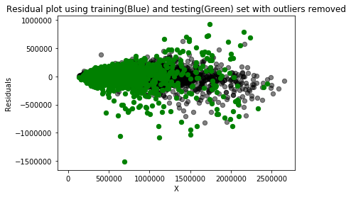

```python
# Plot outputs
plt.scatter(regr_rf.predict(X_train_out), regr_rf.predict(X_train_out)-y_train_out,  color='black', s=40, alpha=0.5)
plt.scatter(regr_rf.predict(X_test_out), regr_rf.predict(X_test_out)-y_test_out,  color='green', s=40)
plt.hlines(y=0, xmin=0, xmax=50)
plt.title('Residual plot using training(Blue) and testing(Green) set with outliers removed')
plt.ylabel('Residuals')
plt.xlabel('X')
plt.show()
```

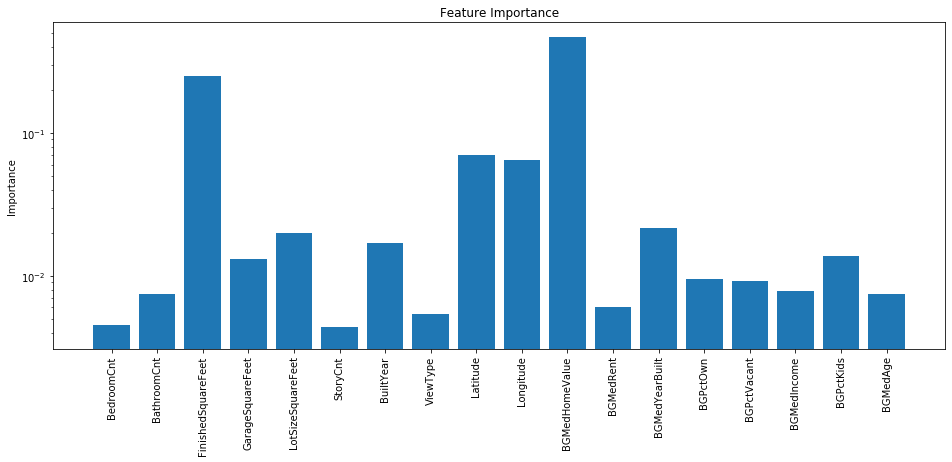

```python
# REf: https://hackernoon.com/predicting-the-price-of-houses-in-brooklyn-using-python-1abd7997083b
regressionTree_imp = regr_rf.feature_importances_
plt.figure(figsize=(16,6))
plt.yscale('log',nonposy='clip')
plt.bar(range(len(regressionTree_imp)),regressionTree_imp,align='center')
plt.xticks(range(len(regressionTree_imp)),X_out,rotation='vertical')
plt.title('Feature Importance')
plt.ylabel('Importance')
plt.show()
```

### Finding patterns in the features that may increase or decrease the accuracy of the model by looking at the prediction errors -- Random Forest Predicted Values

```python
# Append the predictions to testing set
X_test_out['rf_predictions'] = y_pred_out_rf[:]
```